# Willamette River Salmon

Allison Hacker, Sydney Rilum, Elmera Azadpour

2/2/2021

## Overview

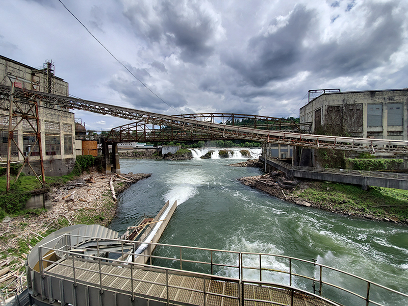

Fish bypass at the Willamette Falls hydroelectric plant. Source: [Portland Gas and Electric](https://portlandgeneral.com/about/willamette-river)

Every year, salmon and steelhead pass make their way from the Pacific Ocean up Oregeon’s Willamette River to spawn. Fish ladders allow the fish to move past dams and give scientists an opportunity to track their numbers. Daily visual counts of adult fish were conducted at all major dams in the Columbia River basin, including Willamette Falls (see location below). This report will explore adult fish passage at Willamette Falls from 2001 to 2010.

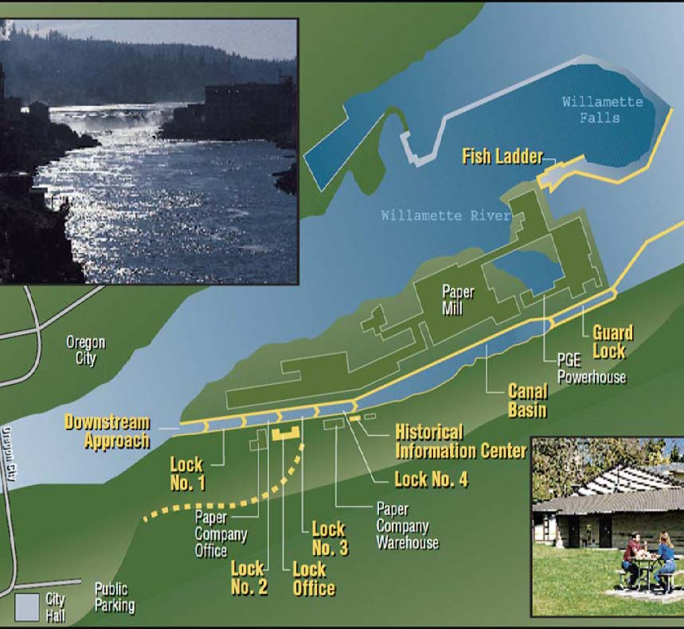

Map of Willamette Falls fish ladder location on the Willamette River. Source: [US Army Corps of Engineers, Portland District Website](https://www.nwp.usace.army.mil/willamette/locks/)

Data obtained from [Columbia River DART](http://www.cbr.washington.edu/dart/query/adult_graph_text) (Data Access in Real Time). Data collected by [Oregon Department of Fish and Wildlife.](https://www.dfw.state.or.us/fish/fish_counts/willamette%20falls.asp)

### Daily Time Series Data

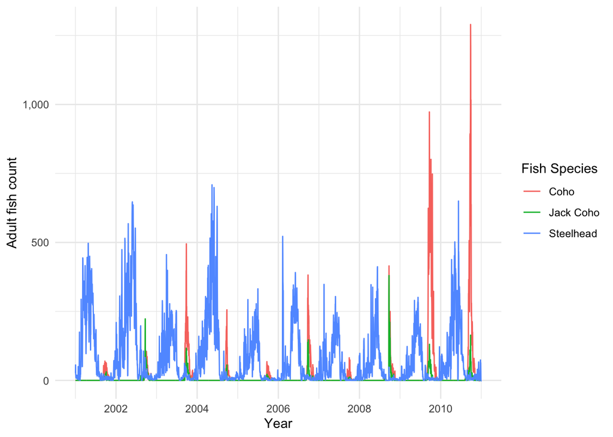

```r
# Read in the data and clean up column names
salmon <- read_csv(here("data", "willamette_fish_passage.csv")) %>%
  clean_names()

# Convert salmon data set into a time series data frame (tsibble)
salmon_ts <- salmon %>%
  mutate(date = lubridate::mdy(date)) %>%  #converts date to readable R form
  as_tsibble(key = NULL, index = date) %>%
  select(date,coho,jack_coho,steelhead)  %>%
  replace(is.na(.), 0) %>%
  pivot_longer(cols = coho:steelhead, #pivoted longer to
  names_to = "species" ,
  values_to = "count")

# Create time series plot
ggplot(salmon_ts, aes(date, count)) +
  geom_line(aes(color = species)) +
  theme_minimal() +
  labs(x = "Year", y = "Adult fish count") +
  scale_color_discrete(name = "Fish Species",
                       breaks = c("coho", "jack_coho", "steelhead"),
                       labels = c("Coho", "Jack Coho", "Steelhead"))+
  scale_y_continuous(labels = scales::comma)
```

**Figure 1.** Time series plot for coho, jack coho, and steelhead salmon species counts at the Willamette Falls fish ladder on the Willamette River in Oregon from years 2001 to 2010. Red line indicates times series counts for Coho, green line for Jack coho and blue line for Steelhead. Data source: [Oregon Department of Fish and Wildlife.](https://www.dfw.state.or.us/fish/fish_counts/willamette%20falls.asp)

**Major trends:**

- Jack coho adult count is low in comparison to Coho and Steelhead through the time series.
- Steelhead adult count appears to be greatest compared to Coho and Jack coho up until later in the 2009 calendar year. This similar increase occurs later in 2010 as well.

### Seasonplots

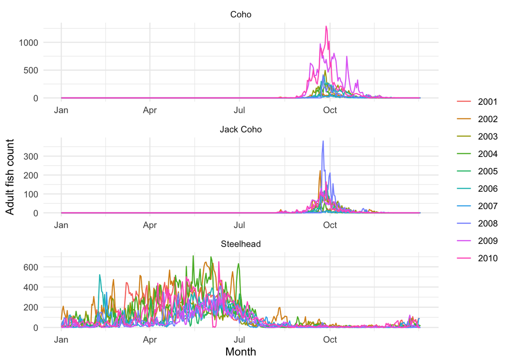

```r
# Create fish name character vector to use on plot
fish_label <- c(`coho` = "Coho", `jack_coho` = "Jack Coho", `steelhead` = "Steelhead")

# Create seasonplots
seasonplot <- salmon_ts %>%
  gg_season(y = count) +
  facet_wrap(~ species, ncol = 1, scales = "free", labeller = as_labeller(fish_label)) +
  theme_minimal() +
  labs(x = "Month",
       y = "Adult fish count") +
  theme(legend.title = element_text("Year"))

seasonplot
```

**Figure 2.** Seasonplots for coho, jack coho, and steelhead salmon species counts at the Willamette Falls fish ladder on the Willamette River in Oregon. Each colored line represents count data for a single year, including the years 2001 to 2010. Note the count scales are different for each salmon species. Data source: [Oregon Department of Fish and Wildlife.](https://www.dfw.state.or.us/fish/fish_counts/willamette%20falls.asp)

### Summary Statistics and Analysis

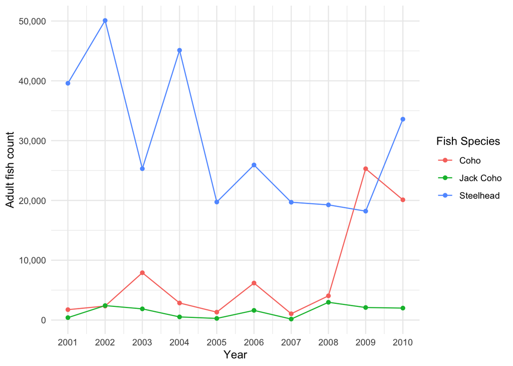

```r
# Summarize annual count by species
salmon_count <- salmon_ts %>%
  index_by(year = ~ year(.)) %>%
  group_by(species) %>%
  summarise(total_count = sum(count))

# Make line graph of annual count by species
ggplot(data = salmon_count, aes(x = year, y = total_count, color = species))+
  geom_line()+
  geom_point()+
  theme_minimal()+
  labs(x = "Year", y = "Adult fish count")+
  scale_color_discrete(name = "Fish Species",
                       breaks = c("coho", "jack_coho", "steelhead"),
                       labels = c("Coho", "Jack Coho", "Steelhead"))+
  scale_x_continuous(breaks = 2001:2010)+
  scale_y_continuous(labels = scales::comma)
```

**Figure 3.** Annual count of adult coho (red), jack coho (green), and steelhead (blue) fish observed at the Willamette Falls fish ladder on the Willamette River from 2001 to 2010. Data source: [Oregon Department of Fish and Wildlife.](https://www.dfw.state.or.us/fish/fish_counts/willamette%20falls.asp)

**Major Trends:**